# Abstract

## Analizando los atributos y viendo que todos manejan el mismo tipo de informacion puedo pasar a usar expand_sra_attributes() sin problemas

```r
rse_gene_SRP078152 <- expand_sra_attributes(rse_gene_SRP078152)
colData(rse_gene_SRP078152)[
    ,
    grepl("^sra_attribute", colnames(colData(rse_gene_SRP078152)))
]
```

```
## DataFrame with 84 rows and 4 columns
##            sra_attribute.donor sra_attribute.hours_post-infection
##                    <character>                        <character>
## SRR3771356                   9                                  6
## SRR3771357                   9                                  6
## SRR3771359                   9                                  6
## SRR3771360                   9                                  6
## SRR3771361                   9                                  6
## ...                        ...                                ...
## SRR3771437                  11                                 48
## SRR3771438                  11                                 24
## SRR3771439                  11                                 24
## SRR3771440                  11                                 24
## SRR3771441                  11                                 24
##            sra_attribute.source_name sra_attribute.treatment
##                          <character>             <character>
## SRR3771356    primary monocyte-der..                    mock
## SRR3771357    primary monocyte-der..                    mock
## SRR3771359    primary monocyte-der..                     LPS
## SRR3771360    primary monocyte-der..                     LPS
## SRR3771361    primary monocyte-der..                    EBOV
## ...                              ...                     ...
## SRR3771437    primary monocyte-der..                   RESTV
## SRR3771438    primary monocyte-der..                EBOV/LPS
## SRR3771439    primary monocyte-der..                EBOV/LPS
## SRR3771440    primary monocyte-der..               RESTV/LPS
## SRR3771441    primary monocyte-der..               RESTV/LPS
```

## Asignaremos el tipo formato correcto a los atributos que los necesiten

```r
rse_gene_SRP078152$sra_attribute.donor <- factor(rse_gene_SRP078152$sra_attribute.donor)
rse_gene_SRP078152$sra_attribute.treatment <- factor(rse_gene_SRP078152$sra_attribute.treatment)
rse_gene_SRP078152$`sra_attribute.hours_post-infection` <- as.numeric(rse_gene_SRP078152$`sra_attribute.hours_post-infection`)
summary(as.data.frame(colData(rse_gene_SRP078152)[
    ,
    grepl("^sra_attribute.[donor|treatment]", colnames(colData(rse_gene_SRP078152)))
]))
```

```
##  sra_attribute.donor sra_attribute.treatment
##  10:28               EBOV     :18
##  11:28               EBOV/LPS : 6
##  9 :28               LPS      :18
##                      mock     :18
##                      RESTV    :18
##                      RESTV/LPS: 6
```

```r
unique(rse_gene_SRP078152$`sra_attribute.hours_post-infection`)
```

```
## [1]  6 24 48
```

```r
rse_gene_SRP078152$hours <- factor(ifelse(rse_gene_SRP078152$`sra_attribute.hours_post-infection` <= 24, 24, 48))
table(rse_gene_SRP078152$hours)
```

```
##
## 24 48
## 60 24
```

# Limpieza de los datos

## Analizaremos la calidad de las muestras pra determinar si dejarlas o limpiarlas

```r
rse_gene_SRP078152$assigned_gene_prop <- rse_gene_SRP078152$recount_qc.gene_fc_count_all.assigned / rse_gene_SRP078152$recount_qc.gene_fc_count_all.total
summary(rse_gene_SRP078152$assigned_gene_prop)
```

```
##    Min. 1st Qu.  Median    Mean 3rd Qu.    Max.
## 0.08803 0.28596 0.35646 0.36274 0.43571 0.58170
```

## Viendo que la mayoria de las muestras tienen una calidad muy baja, utilizare como punto de corte la mediana

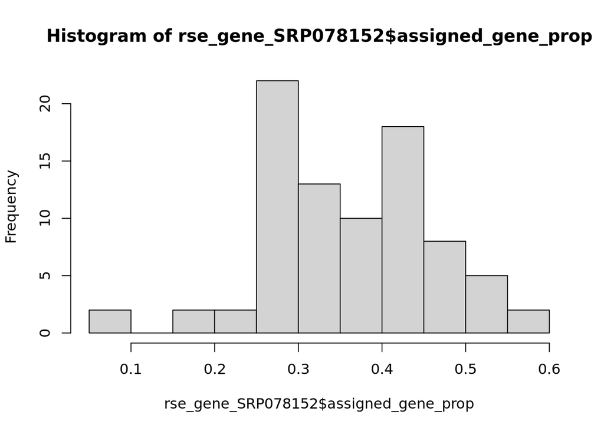

```r
# Guardemos por si cambio de opinion
rse_gene_SRP078152_unfiltered <- rse_gene_SRP078152
hist(rse_gene_SRP078152$assigned_gene_prop)
```

```r
table(rse_gene_SRP078152$assigned_gene_prop < 0.35)
```

```
##
## FALSE  TRUE
##    43    41
```

```r
rse_gene_SRP078152 <- rse_gene_SRP078152[, rse_gene_SRP078152$assigned_gene_prop > 0.35]
```

## Ahora que ya limpiamos las muestra, procedere a limpiar los genes

```r
gene_means <- rowMeans(assay(rse_gene_SRP078152, "counts"))
summary(gene_means)
```

```
##     Min.  1st Qu.   Median     Mean  3rd Qu.     Max.
##      0.0      0.0      0.3    320.8     25.5 613220.5
```

## Viendo que incluso en mi primer quantile tengo una expresion genetica muy mala, de 0, usare la meiana para determinarla como umbral para eliminar los genes

```r
rse_gene_SRP078152 <- rse_gene_SRP078152[gene_means > 0.3, ]
dim(rse_gene_SRP078152)
```

```
## [1] 31818    43
```

```r
round(nrow(rse_gene_SRP078152) / nrow(rse_gene_SRP078152_unfiltered) * 100, 2)
```

```
## [1] 49.83
```

```r
dge <- DGEList(
    counts = assay(rse_gene_SRP078152, "counts"),
    genes = rowData(rse_gene_SRP078152)
)
dge <- calcNormFactors(dge)
```

# Expresion diferencial

Pero primero haremos el modelo estadistico

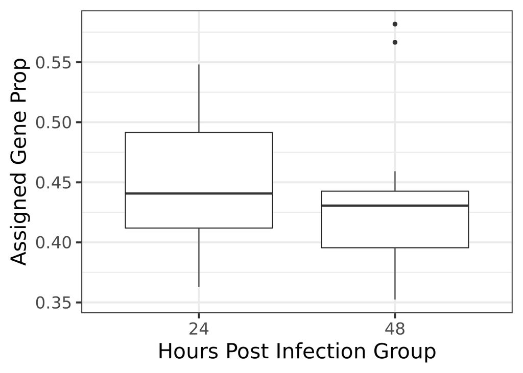

```r
library("ggplot2")
ggplot(as.data.frame(colData(rse_gene_SRP078152)), aes(y = assigned_gene_prop, x = hours)) +
    geom_boxplot() +
    theme_bw(base_size = 20) +
    ylab("Assigned Gene Prop") +
    xlab("Hours Post Infection Group")
```

```r
app <- ExploreModelMatrix::ExploreModelMatrix(
  sampleData = colData(rse_gene_SRP078152)[, c("hours", "assigned_gene_prop",
                                           "sra_attribute.treatment"
           )],
  designFormula = ~ hours + assigned_gene_prop + sra_attribute.treatment
)
if (interactive()) shiny::runApp(app)
```

# Normalizacion

## Ya que tengo el modelo estadistico puedo proceder a usar limma para el estudio de expresion diferencial

```r
mod <- model.matrix( ~ hours + assigned_gene_prop + sra_attribute.treatment,
                    data = colData(rse_gene_SRP078152))
colnames(mod)
```

```
## [1] "(Intercept)"                      "hours48"
## [3] "assigned_gene_prop"               "sra_attribute.treatmentEBOV/LPS"
## [5] "sra_attribute.treatmentLPS"       "sra_attribute.treatmentmock"
## [7] "sra_attribute.treatmentRESTV"     "sra_attribute.treatmentRESTV/LPS"
```

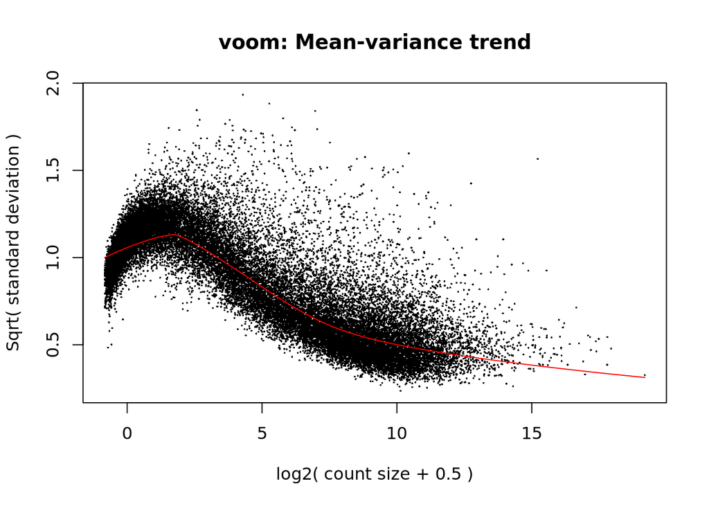

```r
vGene <- voom(dge, mod, plot = TRUE)
```

```r
eb_results <- eBayes(lmFit(vGene))

de_results <- topTable(
    eb_results,
    coef = 2,
    number = nrow(rse_gene_SRP078152),
    sort.by = "none"
)
dim(de_results)
```

```
## [1] 31818    16
```

```r
head(de_results)
```

```
##                    source type score phase           gene_id
## ENSG00000223972.5  HAVANA gene  1735    NA ENSG00000223972.5
## ENSG00000278267.1 ENSEMBL gene    68    NA ENSG00000278267.1
## ENSG00000227232.5  HAVANA gene  1351    NA ENSG00000227232.5
## ENSG00000243485.5  HAVANA gene  1021    NA ENSG00000243485.5
## ENSG00000237613.2  HAVANA gene  1219    NA ENSG00000237613.2
## ENSG00000186092.4  HAVANA gene   918    NA ENSG00000186092.4
##                                            gene_type   gene_name level
## ENSG00000223972.5 transcribed_unprocessed_pseudogene     DDX11L1     2
## ENSG00000278267.1                              miRNA   MIR6859-1     3
## ENSG00000227232.5             unprocessed_pseudogene      WASH7P     2
## ENSG00000243485.5                            lincRNA MIR1302-2HG     2
## ENSG00000237613.2                            lincRNA     FAM138A     2
## ENSG00000186092.4                     protein_coding       OR4F5     2
##                            havana_gene        tag       logFC   AveExpr
## ENSG00000223972.5 OTTHUMG00000000961.2       <NA>  0.60544902 -3.500400
## ENSG00000278267.1                 <NA>       <NA> -0.15498191 -3.498206
## ENSG00000227232.5 OTTHUMG00000000958.1       <NA>  0.06182482  2.649443
## ENSG00000243485.5 OTTHUMG00000000959.2 ncRNA_host  0.90727389 -3.706567
## ENSG00000237613.2 OTTHUMG00000000960.1       <NA> -0.42187677 -4.930770
## ENSG00000186092.4 OTTHUMG00000001094.2       <NA>  0.15184673 -4.941784
##                            t    P.Value adj.P.Val         B
## ENSG00000223972.5  1.2528766 0.21758646 0.4438365 -5.090406
## ENSG00000278267.1 -0.3923643 0.69688954 0.8476483 -5.729289
## ENSG00000227232.5  0.4271424 0.67158537 0.8312005 -6.736031
## ENSG00000243485.5  1.7205160 0.09313218 0.2637807 -4.480852
## ENSG00000237613.2 -1.2215718 0.22908024 0.4570687 -5.238218
## ENSG00000186092.4  0.4760411 0.63665671 0.8106100 -5.835931
```

```r
table(de_results$adj.P.Val < 0.05)
```

```
##
## FALSE  TRUE
## 26807  5011
```

```r
round(table(de_results$adj.P.Val < 0.05)[2] / length(de_results$adj.P.Val) * 100, 2)
```

```
##  TRUE
## 15.75
```

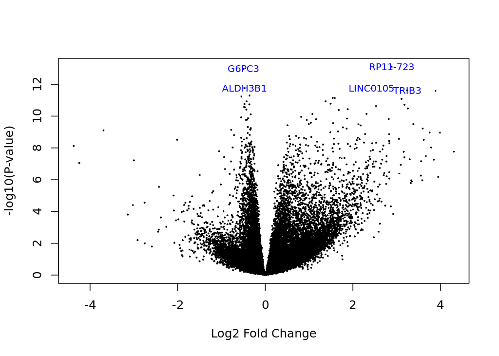

```r
volcanoplot(eb_results, coef = 2, highlight = 5, names = de_results$gene_name)
```